# Snow Data Assignment: Web Scraping, Functions, and Iteration

Tad Trimarco

2-7-2022

# Simple web scraping

R can read html using either rvest, xml, or xml2 packages. Here we are going to navigate to the Center for Snow and Avalance Studies [Website](https://snowstudies.org/archived-data/) and read a table in. This table contains links to data we want to programatically download for three sites. We don’t know much about these sites, but they contain incredibly rich snow, temperature, and precip data.

## Reading an html

### Extract CSV links from webpage

```r
site_url <- 'https://snowstudies.org/archived-data/'

#Read the web url
webpage <- read_html(site_url)

#See if we can extract tables and get the data that way
tables <- webpage %>%
  html_nodes('table') %>%
  magrittr::extract2(3) %>%
  html_table(fill = TRUE)
#That didn't work, so let's try a different approach

#Extract only weblinks and then the URLs!
links <- webpage %>%
  html_nodes('a') %>%
  .[grepl('24hr',.)] %>%
  html_attr('href')
```

## Data Download

### Download data in a for loop

```r
#Grab only the name of the file by splitting out on forward slashes
splits <- str_split_fixed(links,'/',8)

#Keep only the 8th column
dataset <- splits[,8]

#generate a file list for where the data goes
datapath = 'data/'
dir.create(datapath)
file_names <- paste0(datapath,dataset)

for(i in 1:3){
  download.file(links[i],destfile=file_names[i])
}

downloaded <- file.exists(file_names)

evaluate <- !all(downloaded)
```

### Download data in a map

```r
#Map version of the same for loop (downloading 3 files)
if(evaluate == T){
  map2(links[1:3],file_names[1:3],download.file)
}else{print('data already downloaded')}
```

```
## [[1]]
## [1] 0
##
## [[2]]
## [1] 0
##
## [[3]]
## [1] 0
```

## Data read-in

### Read in just the snow data as a loop

```r
#Pattern matching to only keep certain files
snow_files <- file_names %>%
  .[!grepl('SG_24',.)] %>%
  .[!grepl('PTSP',.)]

#empty_data <- list()

# snow_data <- for(i in 1:length(snow_files)){
#   empty_data[[i]] <- read_csv(snow_files[i]) %>%
#     select(Year,DOY,Sno_Height_M)
# }

#snow_data_full <- do.call('rbind',empty_data)

#summary(snow_data_full)
```

### Read in the data as a map function

```r
our_snow_reader <- function(file){
  name = str_split_fixed(file,'/',2)[,2] %>%
    gsub('_24hr.csv','',.)
  df <- read_csv(file) %>%
    select(Year,DOY,Sno_Height_M) %>%
    mutate(site = name)
}

snow_data_full <- map_dfr(snow_files,our_snow_reader)
summary(snow_data_full)
```

```
##       Year           DOY         Sno_Height_M        site
##  Min.   :2003   Min.   :  1.0   Min.   :-3.523   Length:12786
##  1st Qu.:2008   1st Qu.: 92.0   1st Qu.: 0.350   Class :character
##  Median :2012   Median :183.0   Median : 0.978   Mode  :character
##  Mean   :2012   Mean   :183.1   Mean   : 0.981
##  3rd Qu.:2016   3rd Qu.:274.0   3rd Qu.: 1.520
##  Max.   :2021   Max.   :366.0   Max.   : 2.905
##                                 NA's   :4554
```

### Plot snow data

```r
snow_yearly <- snow_data_full %>%
  group_by(Year,site) %>%
  summarize(mean_height = mean(Sno_Height_M,na.rm=T))
```

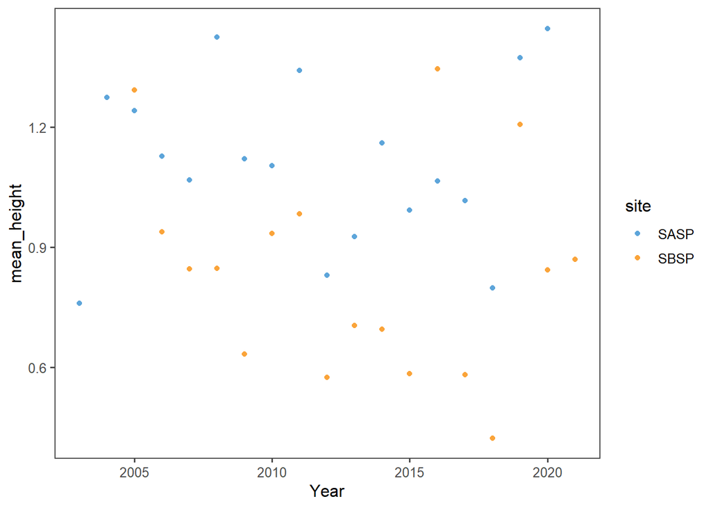

```r
ggplot(snow_yearly,aes(x=Year,y=mean_height,color=site)) +
  geom_point() +
  ggthemes::theme_few() +
  ggthemes::scale_color_few()
```

# Assignment:

1. Extract the meteorological data URLs. Here we want you to use the `rvest` package to get the URLs for the `SASP forcing` and `SBSP_forcing` meteorological datasets.

```r
links_hw <- webpage %>%
  html_nodes('a') %>%
  .[grepl('forcing',.)] %>%
  html_attr('href')
```

2. Download the meteorological data. Use the `download_file` and `str_split_fixed` commands to download the data and save it in your data folder. You can use a for loop or a map function.

```r
#Grab only the name of the file by splitting out on forward slashes
splits_hw <- str_split_fixed(links_hw,'/',8)

#Keep only the 8th column
dataset_hw <- splits_hw[,8]

#generate a file list for where the data goes
#datapath = 'data/'
#dir.create(datapath)

file_names_hw <- paste0(datapath,dataset_hw)

for(i in 1:2){
  download.file(links_hw[i],destfile=file_names_hw[i])
}

downloaded_hw <- file.exists(file_names_hw)

evaluate_hw <- !all(downloaded_hw)
```

3. Write a custom function to read in the data and append a site column to the data.

```r
# this code grabs the variable names from the metadata pdf file
headers <- pdf_text('https://snowstudies.org/wp-content/uploads/2022/02/Serially-Complete-Metadata-text08.pdf') %>%
  readr::read_lines(.) %>%
  trimws(.) %>%
  str_split_fixed(.,'\\.',2) %>%
  .[,2] %>%
  .[1:26] %>%
  str_trim(side = "left")

read_files_hw <- function(file){

                      site_name <- str_split_fixed(file,'_',3)[,2]

                     df <- read_table(file, col_names = headers, skip = 4)  %>%
                     mutate(site = site_name)

}
```

4. Use the `map` function to read in both meteorological files. Display a summary of your tibble.

```r
meteor_data_full <- map_dfr(file_names_hw,read_files_hw)
meteor_data_full
```

```
## # A tibble: 138,336 x 27
##     year month   day  hour minute second `precip [kg m-2 s-1]` `sw down [W m-2]`
##    <dbl> <dbl> <dbl> <dbl>  <dbl>  <dbl>                 <dbl>             <dbl>
##  1  2003    11    10     1      0      0              0                    -9999
##  2  2003    11    10     2      0      0              0.000278             -9999
##  3  2003    11    10     3      0      0              0.000278             -9999
##  4  2003    11    10     4      0      0              0.000278             -9999
##  5  2003    11    10     5      0      0              0.000833             -9999
##  6  2003    11    10     6      0      0              0.000278             -9999
##  7  2003    11    10     7      0      0              0                    -9999
##  8  2003    11    10     8      0      0              0.000278             -9999
##  9  2003    11    10     9      0      0              0.000278             -9999
## 10  2003    11    10    10      0      0              0.000278             -9999
## # ... with 138,326 more rows, and 19 more variables: lw down [W m-2] <dbl>,
## #   air temp [K] <dbl>, windspeed [m s-1] <dbl>, relative humidity [%] <dbl>,
## #   pressure [Pa] <dbl>, specific humidity [g g-1] <dbl>,
## #   calculated dewpoint temperature [K] <dbl>,
## #   precip, WMO-corrected [kg m-2 s-1] <dbl>,
## #   air temp, corrected with Kent et al. (1993) [K] <dbl>,
## #   air temp, corrected with Anderson and Baumgartner (1998)[K] <dbl>, ...
```

5. Make a line plot of mean temp by year by site (using the `air temp [K]` variable). Is there anything suspicious in the plot? Adjust your filtering if needed.

```r
meteor_yearly <- meteor_data_full %>%
  group_by(year,site) %>%
  filter(year != 2003) %>%
  summarize(mean_temp = mean(`air temp [K]`,na.rm=T))
```

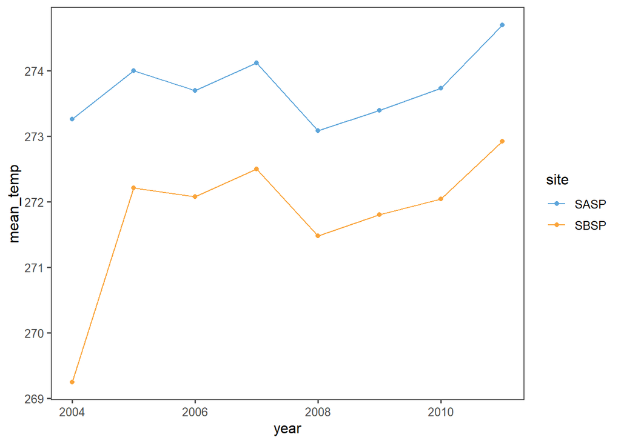

```r
ggplot(meteor_yearly,aes(x=year,y=mean_temp,color=site)) +
  geom_point() + geom_line() +
  ggthemes::theme_few() +
  ggthemes::scale_color_few()
```

The year 2003 had abnormally low temperatures (a mean temperature of almost 10 degrees cooler than the following years). This is likely an issue in how the data was recorded or stored in earlier years, so 2003 is filtered out. It is likely not conceivable that an entire year was on average 10 degrees cooler than the rest of the years.

6. Write a function that makes line plots of monthly average temperature at each site for a given year. Use a for loop to make these plots for 2005 to 2010. Are monthly average temperatures at the Senator Beck Study Plot ever warmer than the Snow Angel Study Plot? Hint: https://ggplot2.tidyverse.org/reference/print.ggplot.html

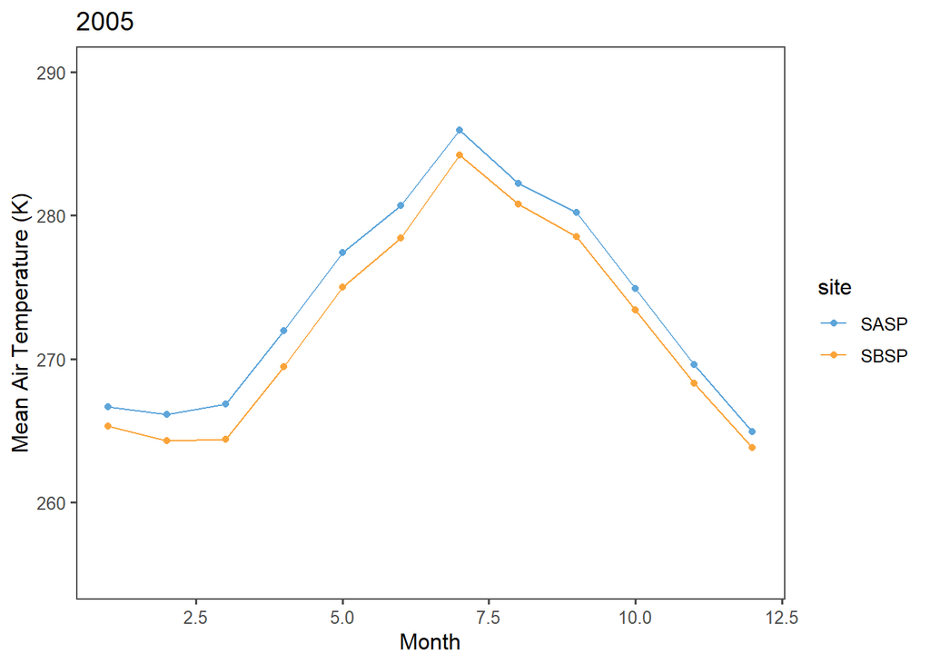

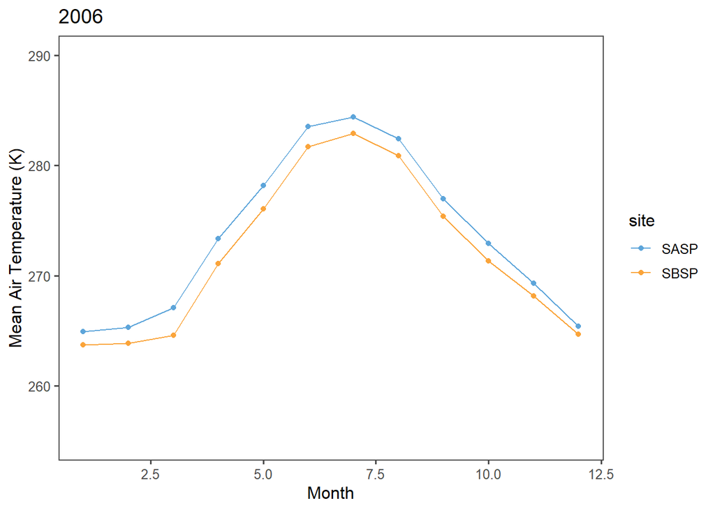

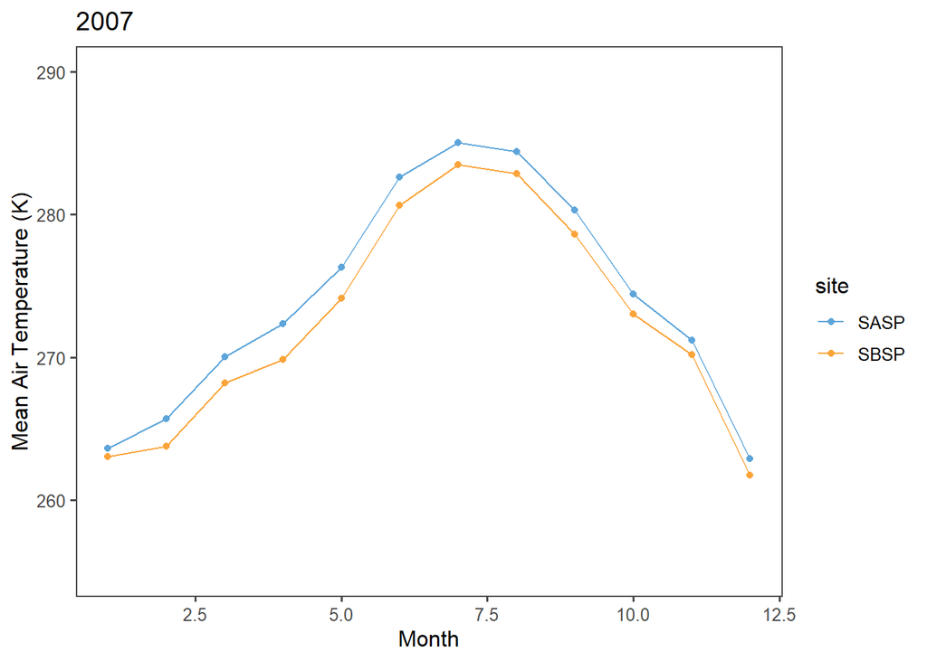

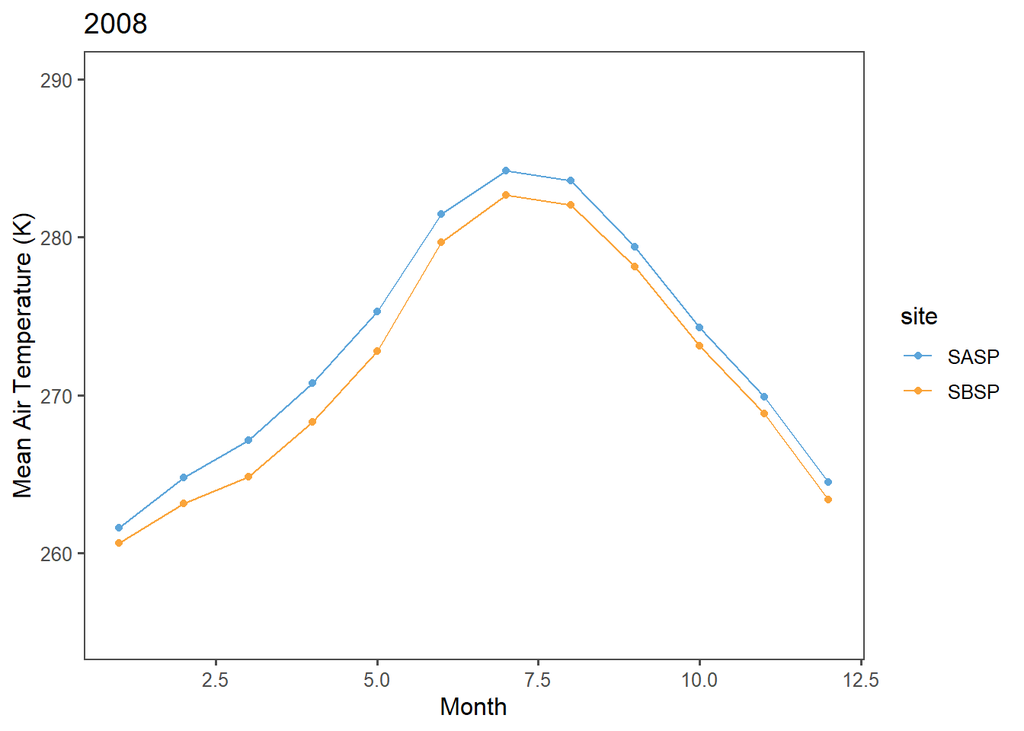

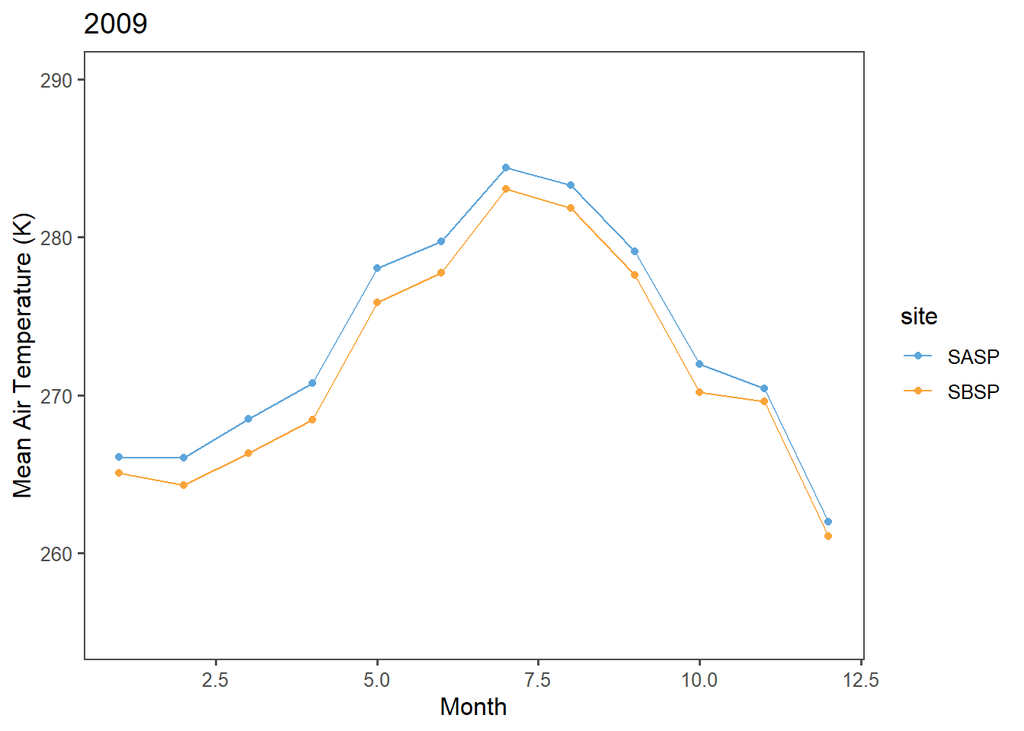

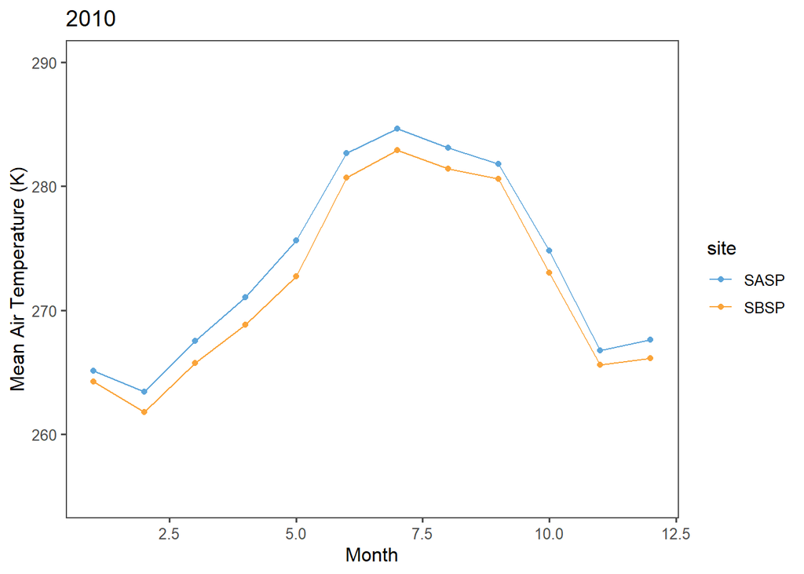

```r
monthly_temp <- function(data = meteor_data_full){

  meteor_monthly <- meteor_data_full %>%
    group_by(year,month,site) %>%
    summarize(mean_temp = mean(`air temp [K]`,na.rm=T))

  meteor_monthly$year <- as.numeric(meteor_monthly$year)

for(i in c(2005:2010)){

   gg_data <- meteor_monthly %>%
               filter(year == i)

    print(ggplot(gg_data,aes(x=month,y=mean_temp,color=site)) +
          geom_point() + geom_line() +
          ggtitle(i) + ylab("Mean Air Temperature (K)") + xlab("Month") +
          ylim(min = 255, max = 290) +
          ggthemes::theme_few() +
          ggthemes::scale_color_few())
  }
}

monthly_temp()
```

Bonus: Make a plot of average daily precipitation by day of year (averaged across all available years). Color each site.

Bonus #2: Use a function and for loop to create yearly plots of precipitation by day of year. Color each site.